# Derived formulas: effect variance and power

Andrey Ziyatdinov

2017-01-24

# 1 Formulas

The power in genetic association studies is a function of the non-centrality parameter (NCP), for which a general formula is the following.

$NCP \approx \beta^2 tr(V^{-1} \Sigma_x)$

| Data | Model |
| --- | --- |
| phenotype | $y \sim (X \beta, V) = (X \beta, \sigma_f^2 F + \sigma_g^2 K + \sigma_r^2 I)$ |
| genotypes | $x \sim (\mu_x, \Sigma_x)$ |

## 1.1 Marginal effect

Given that $x$ is a vector of genotypes with MAF = p, we denote $\sigma_x = 2 p (1 - p)$.

- $N$ is the total sample size.
- $s$ is the family size.
- $N/s$ is the number of families.

| Design | $V$ | $\Sigma_x$ | Final NCP formula |
| --- | --- | --- | --- |
| Unrelated individuals | $\sigma_r^2 I$ | $\sigma_x I$ | $(\beta^2 \sigma_x^2) \frac{N}{\sigma_r^2}$ |
| Common variance (*) | $\sigma_f^2 F + \sigma_r^2 I$ | $\sigma_x I$ | $(\beta^2 \sigma_x^2) \frac{N}{s} (\frac{1}{s \sigma_f^2 + \sigma_r^2} + \frac{s-1}{\sigma_r^2})$ |
| Genetic variance (**) | $\sigma_g^2 K + \sigma_r^2 I$ | $\sigma_x K$ | $(\beta^2 \sigma_x^2) \frac{N}{s} (\frac{1}{\sigma_g^2 + 2 \sigma_r^2 / (1 + s)} + \frac{s-1}{\sigma_g^2 + 2 \sigma_r^2})$ |

- (*) The final NCP formula is derived in the package vignette [Math formulas used in gxefam](https://hemostat.github.io/Public/gxefam/vignettes/formulas.html#common-variance) (Section Common variance).
- (**) The final NCP formula is derived in the package vignette [Math formulas used in gxefam](https://hemostat.github.io/Public/gxefam/vignettes/formulas.html#genetic-variance-for-sib-pairs) (Section Genetic variance for sib-pairs).
  - Note that the derivation is valid for sib-pairs rather than nuclear families.

## 1.2 Gene-environment interaction effect

The formula is the same as for the marginal effect, where the only difference is $\sigma_x = \sigma_{x_g} \sigma_{x_e}$.

Notes

- $x_g$ and $x_e$ are assumed independent.
- If $f$ is the frequency of the environmental exposure, then $\sigma_x = 2 p (1 - p) f (1 - f)$.
- Hint to the derivation:
  - apply QR-decomposition to the matrix $X$ of predictors;
  - that reduces the multi-variate model to an univariate model with the only predictor $(x_g - \mu_{x_g})(x_e - \mu_{x_e})$.

# 2 Power

How can one compare two designs: unrelated and related individuals?

Proposition: Given a population of 50,000 **related** samples, one pools a sample of 5,000 of unrelated samples.

## 2.1 Experiment 1: pool from population-based

| `sim_phen` | $V$ | $\Sigma_x$ | Normalization |
| --- | --- | --- | --- |
| no_rand | $\sigma_f^2 F + \sigma_r^2 I = (\sigma_f^2 + \sigma_r^2) I$ | $\sigma_x I$ | $\sigma_f^2 + \sigma_r^2 = 1$ |
| fam | $\sigma_f^2 F + \sigma_r^2 I$ | $\sigma_x I$ | $\sigma_f^2 + \sigma_r^2 = 1$ |

## 2.2 Experiment 2: pool from family-based

| `sim_phen` | $V$ | $\Sigma_x$ | Normalization |
| --- | --- | --- | --- |
| no_rand | $\sigma_g^2 K + \sigma_r^2 I = (\sigma_g^2 + \sigma_r^2) I$ | $\sigma_x I$ | $\sigma_g^2 + \sigma_r^2 = 1$ |
| gen | $\sigma_g^2 F + \sigma_r^2 I$ | $\sigma_g K$ | $\sigma_g^2 + \sigma_r^2 = 1$ |

## 2.3 Related vs. Unrelated

Parameters for the interaction test:

- p = 0.5 (gen.)
- f = 0.5 (env.)
- power at 0.05 significance level
- the (interaction) effect size 0.1
- related individuals are sib-pairs, for which we know the exact formulas for the power

Varied parameters

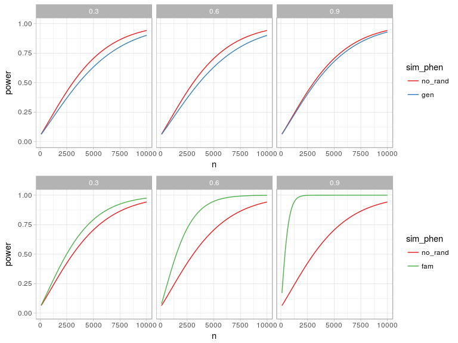

# 3 Addition checks

## 3.1 Extreme cases for `sim_phen` gen

When the values of $\sigma_g^2$ are extreme, either nearly zero (almost unrelated) or nearly one (100% heritability), the two designs, unrelated and genetically related, show the same power (indentical lines on Figure).

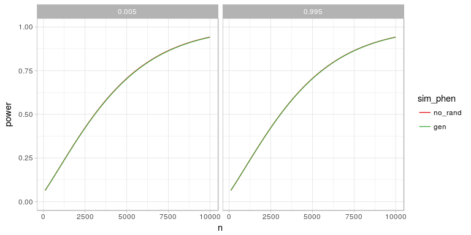

## 3.2 Nuclear families vs. sib-pairs

The sib-pairs design has slightly more power than the nuclear-family design.

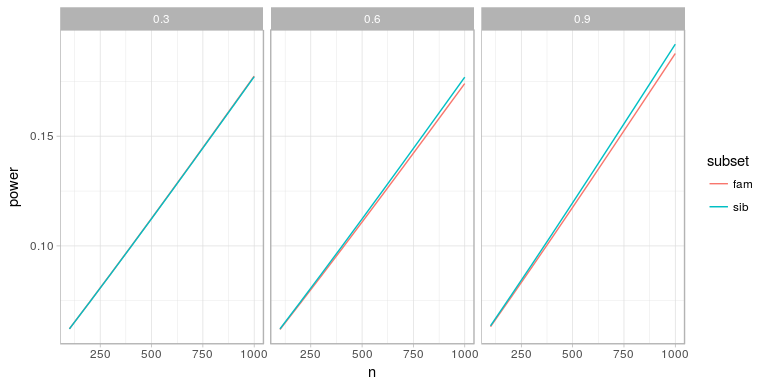

Note: we estimated the power for nuclear-families using the general formula $\beta^2 tr(V^{-1} \Sigma_x)$.